# CProj1

Sneha Bhattacharjee

10/17/2020

### Introduction

In this peer graded assignment, i will be investigating the exponential distribution in R and hence compare it with the Central Limit Theorem. I will be investigating the distribution of averages of 40 exponentials. A total of 1000 simulations will be done.

### Load packages and library

For the purpose of this analysis, i will be using the library ‘ggplot2’.

```r
library(ggplot2)
```

### Illustration of simulations

1. Show the sample mean and compare it to theoretical mean of distribution obtained. As per given instructions, the exponential distributions can be simulated in R using rexp(n, lambda) where, lambda is rate parameter. The simulation is repeated 1000 times here. The theoretical mean of exponential distribution is 1/lambda and the standard deviation is also 1/lambda. Here, for 1000 simulations, lambda is considered 0.2 and sample size ,i.e, n is 40.

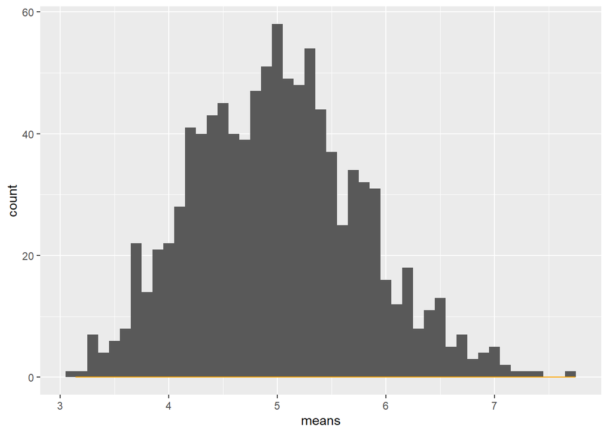

```r
#Setting the seed to ensure reproduceability
set.seed(11081990)

#Setting lambda as 0.2
lambda <- 0.2
#Set values of n
n <- 40

#Obtain the sample mean of 1 simulation with the above parameters
#Obtain sample mean of 1000 simulations with the same above parameters
#Calculate the mean of this simulation of sample means
expoDist <- matrix(data=rexp(n * 1000, lambda), nrow=1000)
expoDistMeans <- data.frame(means=apply(expoDist, 1, mean))

#Plot the means obtained
ggplot(data = expoDistMeans, aes(x = means)) +
  geom_histogram(binwidth=0.1) +  stat_function(fun = dnorm, color = "orange") +
  scale_x_continuous(breaks=round(seq(min(expoDistMeans$means), max(expoDistMeans$means), by=1)))
```

#Theoretical mean that is the centre of distribution is

```r
th <- 1/lambda
th  #Let Th be the expected mean
```

```
## [1] 5
```

```r
mean1000 <- mean(expoDistMeans$means)
mean1000
```

```
## [1] 5.002927
```

The centre of distribution of sample means of 40 exponentials is close to the theoretical center of the distribution.

### 2. Show how variable the sample is (via variance) and compare it to the theoretical variance of the distribution.

```r
#Find the expected standard deviation
sd <- 1/lambda/sqrt(n)
sd
```

```
## [1] 0.7905694
```

```r
#Variance of standard deviation obtained as
Vare <- sd^2
Vare
```

```
## [1] 0.625
```

```r
sd_x <- sd(expoDistMeans$means)
sd_x
```

```
## [1] 0.7767084
```

```r
Var_x <- var(expoDistMeans$means)
Var_x
```

```
## [1] 0.6032759
```

We can observe that the standar deviations are very close in value. Although minor differences exist as variance is the square of standard deviation.

### 3.To show that distribution is approximately normal.

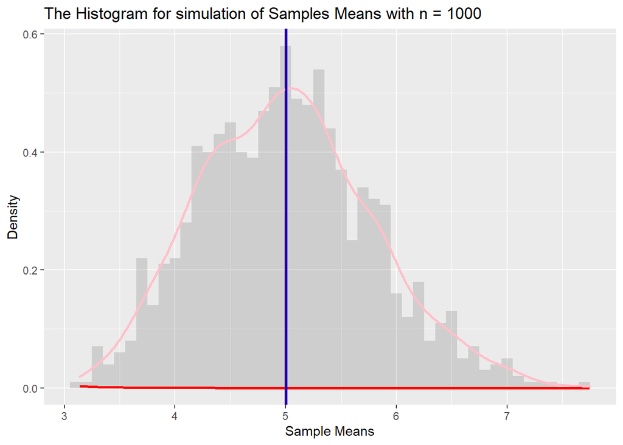

```r
#To plot the sample means obtained from the simulation.
ggplot(data = expoDistMeans, aes(x = means)) +
  geom_histogram(binwidth=0.1, aes(y=..density..), alpha=0.2) +
  stat_function(fun = dnorm, arg = list(mean = th , sd = sd), colour = "red", size=1) +
  geom_vline(xintercept = th, size=1, colour="#CC0000") +
  geom_density(colour="pink", size=1) +
  geom_vline(xintercept = mean1000, size=1, colour="#0000CC") +
  scale_x_continuous(breaks=seq(th-3,th+3,1), limits=c(th-3,th+3))  + ggtitle("The Histogram for simulation of Samples Means with n = 1000") + scale_x_continuous("Sample Means") + ylab("Density")
```